## 单变量分析

#### 数据集的结构

有13个变量组成的1599个数据； x是唯一标识符； 其他12个变量是：fixed.acidity, volatile.acidity, citric.acid, residual.sugar, chlorides, free.sulfur.dioxide, total.sulfur.dioxide, density, pH, sulphates, alcohol, quality；

#### 数据集中的主要变量

最主要的变量是 quality质量，也是这次分析的主要目标； 得分从0-10，大部分数据集中在5-6，分布接近正态分布

#### 异常数据

citric acid的分布不太正常，因为与同是酸度的fixed acidity 和 volatile acidity的分布不一致，后2个分布符合ph的正态分布； citric acid 应该是缺失了大量数据，或者部分数据不可用导致，具体可以看下图：

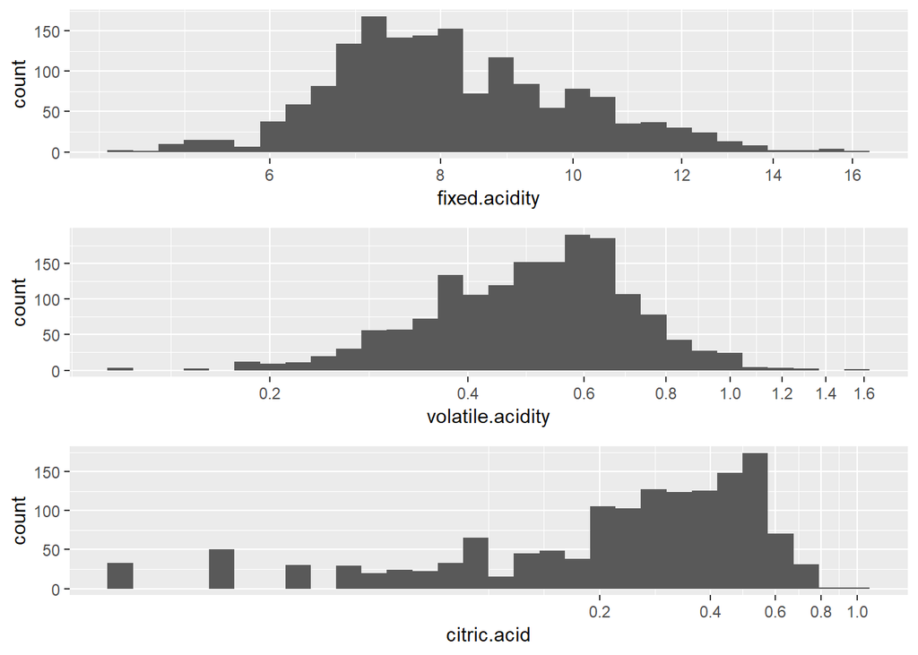

```r
grid.arrange(ggplot(aes(x = fixed.acidity), data =pf ) +
               geom_histogram() +
               scale_x_log10(breaks = seq(4,16,2)),
             ggplot(aes(x = volatile.acidity), data =pf ) +
               geom_histogram() +
               scale_x_log10(breaks = seq(0,1.6, 0.2)),
             ggplot(aes(x = citric.acid), data =pf ) +
               geom_histogram() +
               scale_x_log10(breaks = seq(0,1,0.2)),
             ncol = 1
             )
```

## 新建指示评级

质量评级，把葡萄酒质量分为优质“good”（质量分7-10）、均质“average”（质量分5-6）、差“bad”（质量分0-4）

```r
pf$rating <- ifelse(pf$quality  < 5, 'bad',
                    ifelse( pf$quality  < 7, 'average', 'good'))
pf$rating <- ordered(pf$rating , levels = c('bad','average', 'good'))
summary(pf$rating)
```

```
##     bad average    good
##      63    1319     217
```

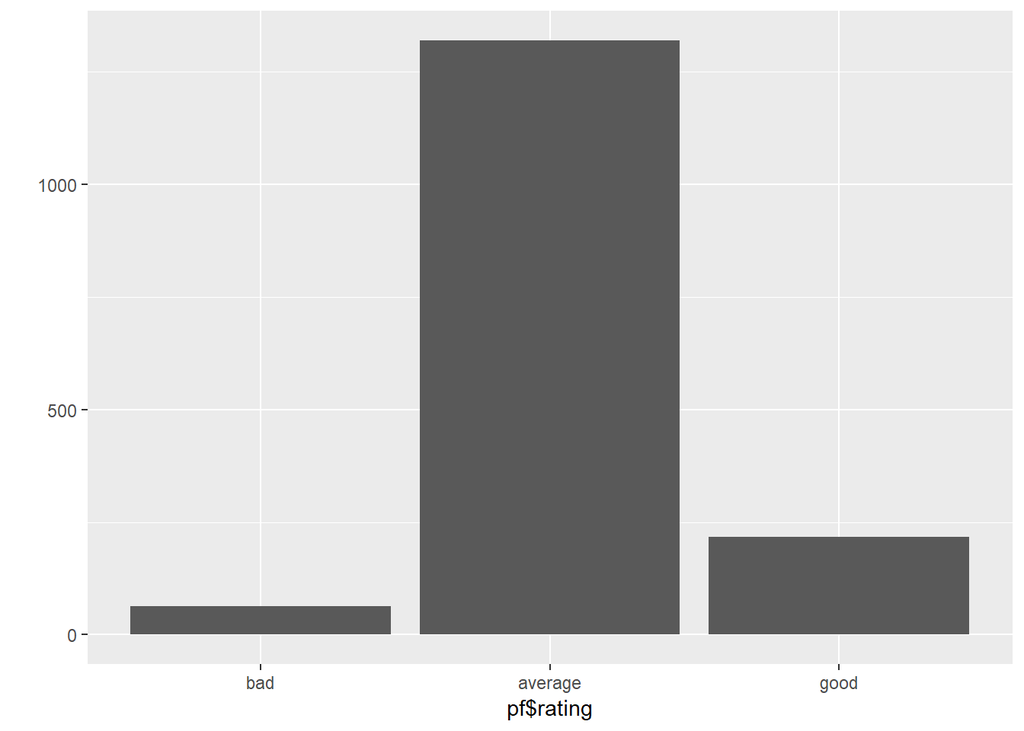

```r
qplot(pf$rating)
```

## 双变量

#### 箱线图

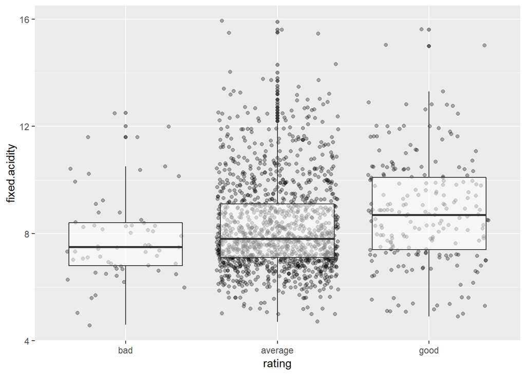

```r
ggplot(aes(rating, fixed.acidity), data = pf) +
  geom_jitter( alpha = 0.3)  +
  geom_boxplot( alpha = 0.5)
```

> 图中可以看到，随着葡萄酒质量评级的提高，fixed acidity随着提高，说明很可能fixed acidity跟质量是正相关的；

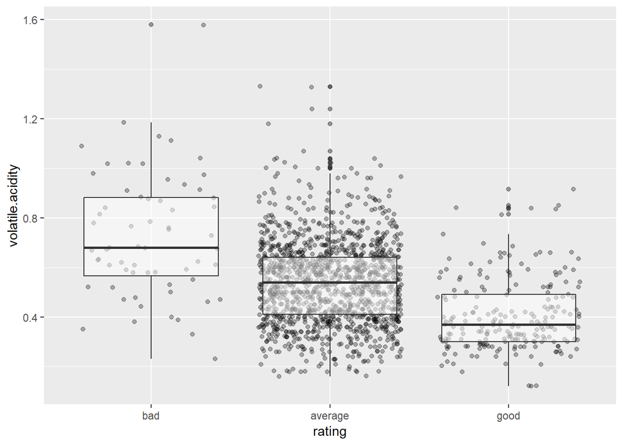

```r
ggplot(aes(rating, volatile.acidity), data = pf) +
  geom_jitter( alpha = 0.3)  +
  geom_boxplot( alpha = 0.5)
```

> 图中可以看到，随着葡萄酒质量评级的提高，volatile acidity随着规律性的降低，说明很可能volatile acidity 跟质量是负相关的;

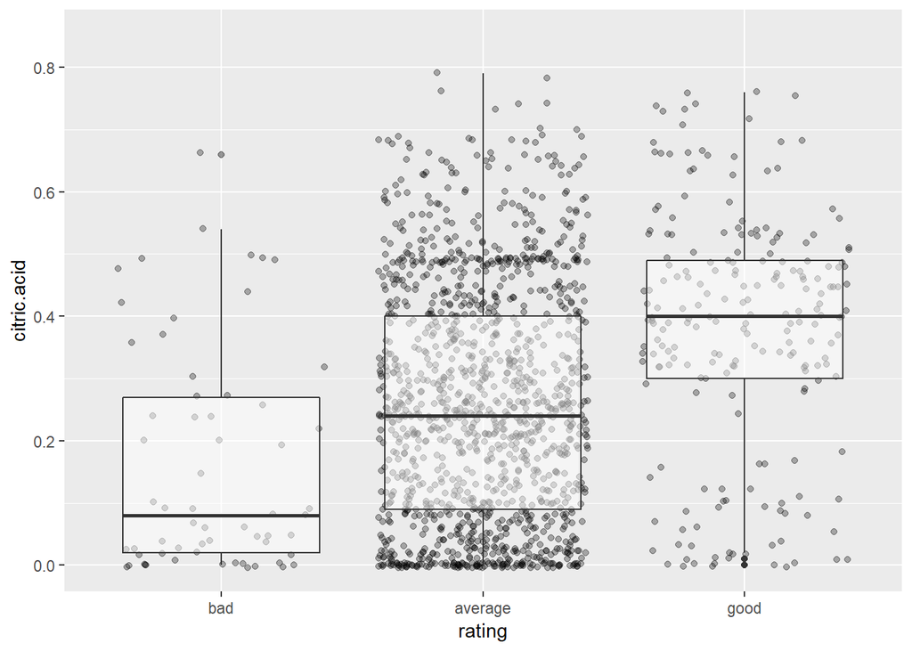

```r
ggplot(aes(rating, citric.acid), data = pf) +
  geom_jitter( alpha = 0.3)  +
  geom_boxplot( alpha = 0.5)+
  coord_cartesian(ylim = c(0, 0.85))
```

> 图中可以看到，随着葡萄酒质量评级的提高，citric acid随着提高，说明很可能citric acid跟质量是正相关的；

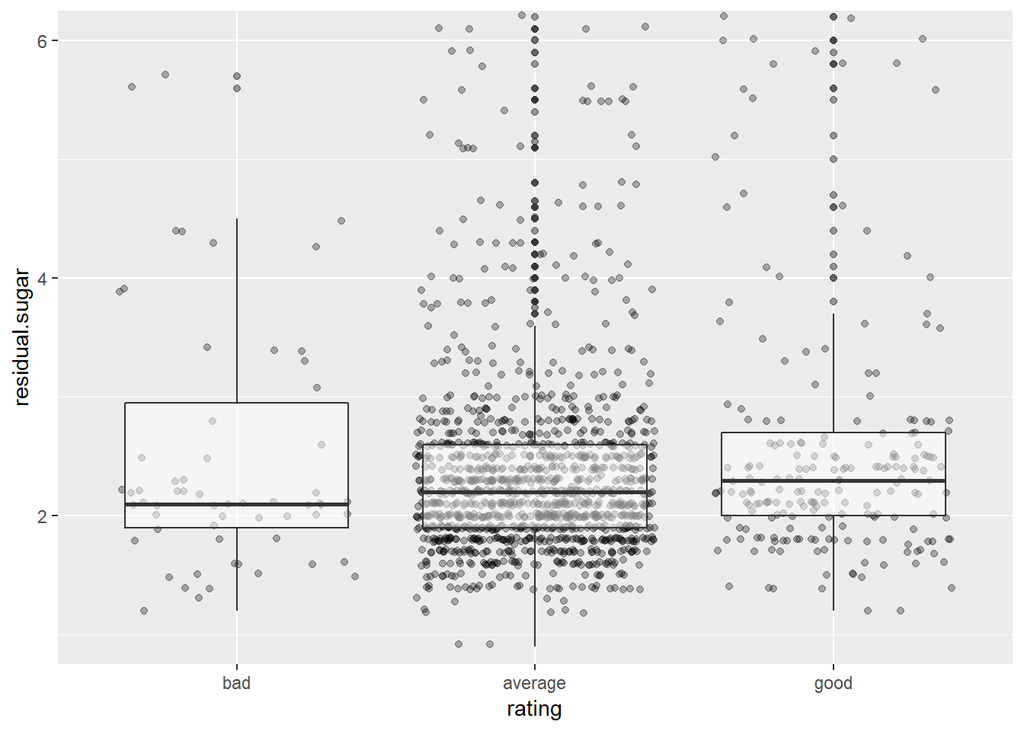

```r
ggplot(aes(rating, residual.sugar), data = pf) +
  geom_jitter( alpha = 0.3)  +
  geom_boxplot( alpha = 0.5)+
  coord_cartesian(ylim = c(1, 6))
```

> 排除了较大的离散值后,从图中可以看到,随着葡萄酒质量评级的提高，residual.sugar也同样升高，但是趋势不太明显，而且还是有很多离散值存在，说明residual sugar可能与葡萄酒质量之间有正相关性，但相关强度应该不大；

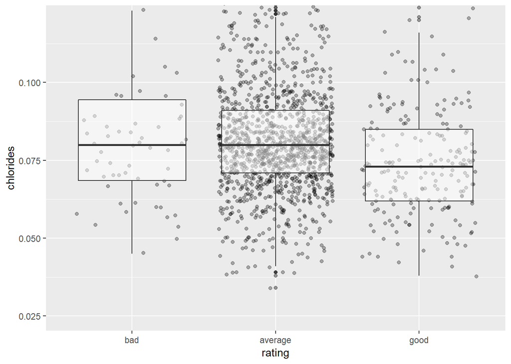

```r
ggplot(aes(rating, chlorides), data = pf) +
  geom_jitter( alpha = 0.3)  +
  geom_boxplot( alpha = 0.5)+
  coord_cartesian(ylim = c(0.025, 0.12))
```

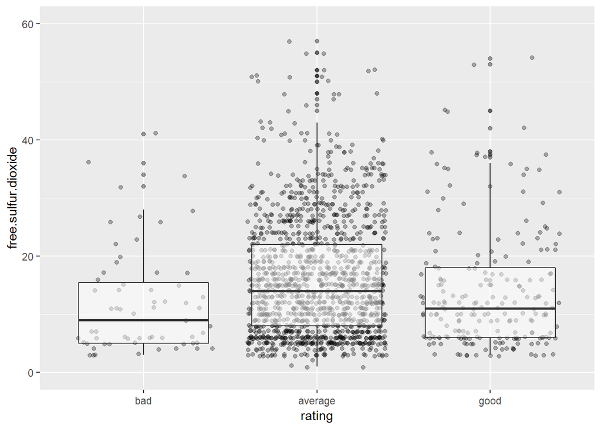

```r
ggplot(aes(rating, free.sulfur.dioxide), data = pf) +
  geom_jitter( alpha = 0.3)  +
  geom_boxplot( alpha = 0.5)+
  coord_cartesian(ylim = c(0, 60))
```

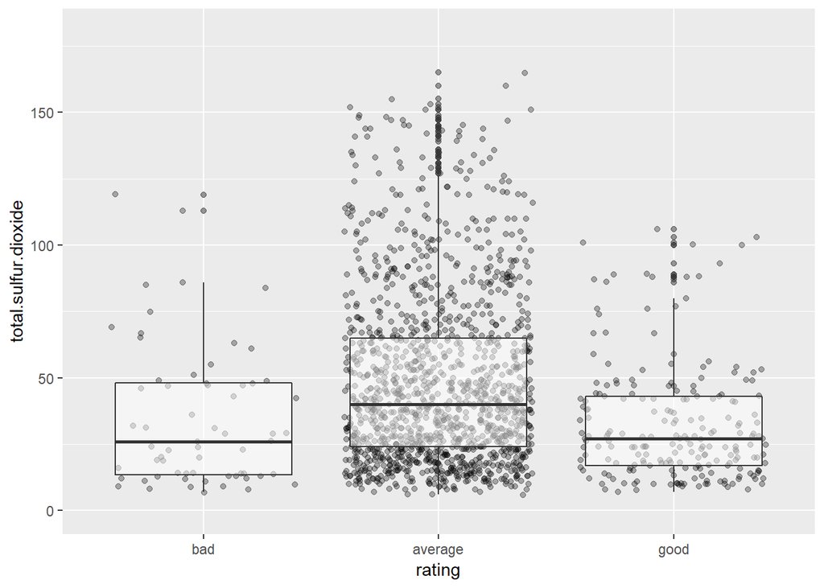

```r
ggplot(aes(rating, total.sulfur.dioxide), data = pf) +
  geom_jitter( alpha = 0.3)  +
  geom_boxplot( alpha = 0.5)+
  coord_cartesian(ylim = c(0, 180))
```

> 图中可以看到，随着葡萄酒质量评级的提高，total sulfur dioxide先变大后变小，没有规律性变化，说明很可能total sulfur dioxide与葡萄酒质量之间并没有相关性；

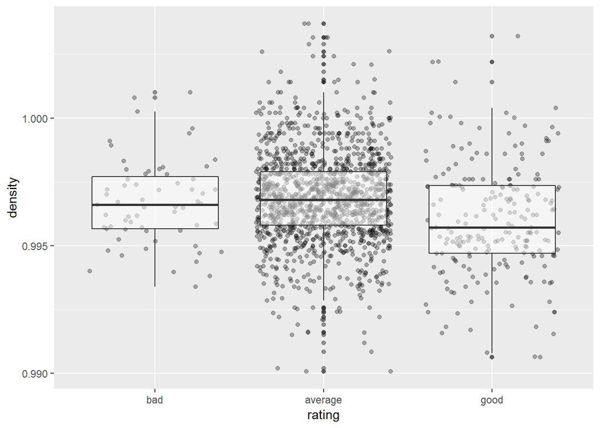

```r
ggplot(aes(rating, density), data = pf) +
  geom_jitter( alpha = 0.3)  +
  geom_boxplot( alpha = 0.5)
```

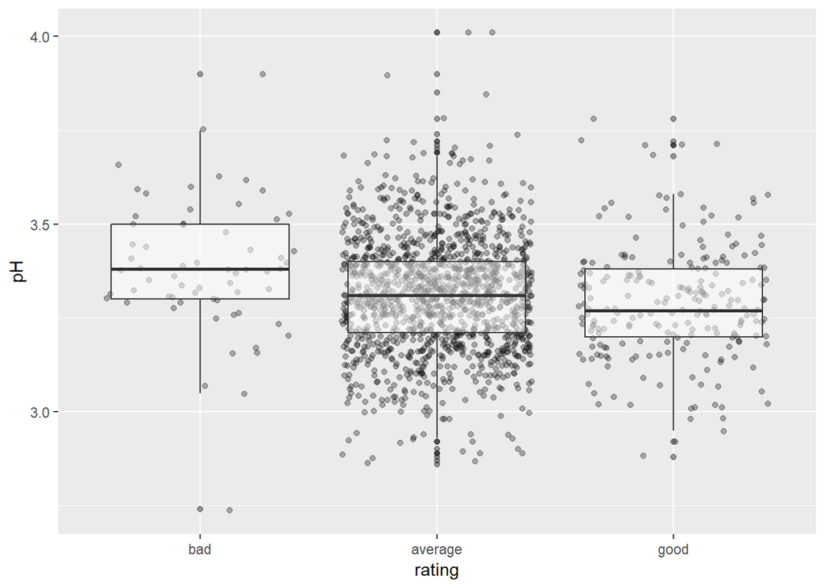

```r
ggplot(aes(rating, pH), data = pf) +
  geom_jitter( alpha = 0.3)  +
  geom_boxplot( alpha = 0.5)
```

> 图中可以看到，随着葡萄酒质量评级的提高，pH 随着规律性的降低，说明很可能pH 跟质量是 负相关的

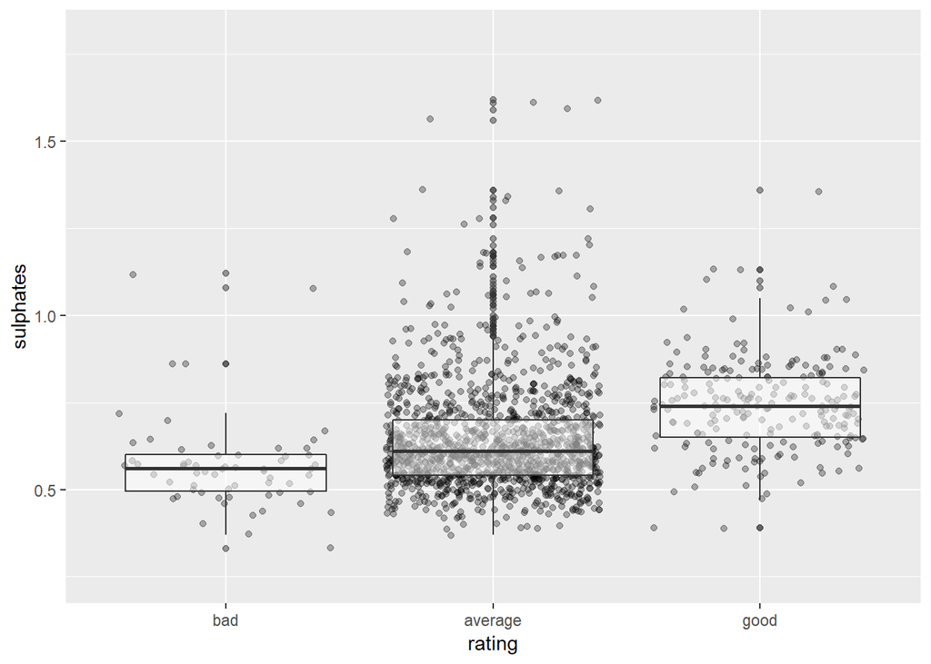

```r
ggplot(aes(rating, sulphates), data = pf) +
  geom_jitter( alpha = 0.3)  +
  geom_boxplot( alpha = 0.5)+
  coord_cartesian(ylim = c(0.25, 1.8))
```

> 图中可以看到，随着葡萄酒质量评级的提高，sulphates随着提高，说明很可能sulphates跟质量是正相关的；

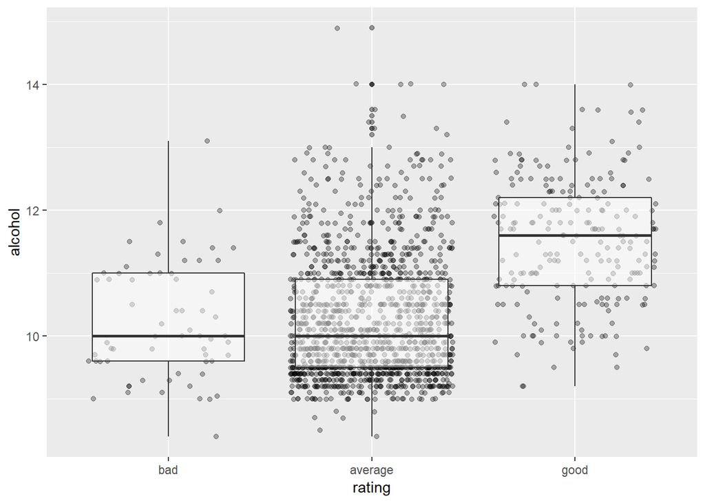

```r
ggplot(aes(rating, alcohol), data = pf) +
  geom_jitter( alpha = 0.3)  +
  geom_boxplot( alpha = 0.5)
```

> 图中可以看到，随着葡萄酒质量评级的提高，alcohol随着提高，说明很可能alcohol 跟质量是正相关的；

#### 小结

- 好像fixed acidity, citric acid, sulphates ， alcohol 跟质量是正相关的；
- volatile acidity ， pH 跟质量是 负相关的；
- density跟单变量分析结果不同，似乎不起作用；

## 双变量分析

#### 与质量的关系

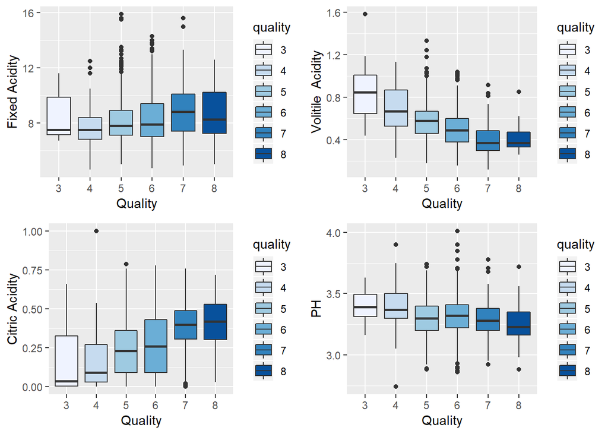

```r
grid.arrange(ggplot(data = pf, aes(x = quality, y = fixed.acidity, fill = quality)) +
               scale_fill_brewer(palette = "Blues")+
               xlab('Quality') +
               ylab('Fixed Acidity') +
               geom_boxplot(),
             ggplot(data = pf, aes(x = quality, y = volatile.acidity, fill = quality)) +
               scale_fill_brewer(palette = "Blues")+
               xlab('Quality') +
               ylab('Volitile  Acidity') +
               geom_boxplot(),
             ggplot(data = pf, aes(x = quality, y = citric.acid, fill = quality)) +
               scale_fill_brewer(palette = "Blues")+
               xlab('Quality') +
               ylab('Citric Acidity') +
               geom_boxplot(),
             ggplot(data = pf, aes(x = quality, y = pH, fill = quality)) +
               scale_fill_brewer(palette = "Blues")+
               xlab('Quality') +
               ylab('PH') +
               geom_boxplot())
```

[figure not shown]

```r
ggplot(data = pf, aes( x = quality, y = alcohol, fill = rating)) +
  geom_boxplot() +
  scale_fill_brewer(palette = "Blues")+
  xlab('Alcohol') +
  ylab('Volatile Acidity')
```

从箱线图中可以看出，fixed acidity, citric acid, sulphates，alcohol 与葡萄酒质量正相关，volatile acidity ， pH 跟质量是负相关的。 从相关性测试中，观察到类似的趋势；

#### 其他情况

sulfur dioxide（二氧化硫）有点意思，与total 和free sulfur dioxide 高度相关，很容易理解，但是它们却跟 sulphates（硫酸盐） 不相关。

#### 相关性强弱：

```r
corr <- NULL

for (i in names(pf)){
  corr[i] <- cor.test(as.numeric(pf[,i]),
                      as.numeric(pf$quality))$estimate
  }

corr
```

```
##                    X        fixed.acidity     volatile.acidity
##           0.06645261           0.12405165          -0.39055778
##          citric.acid       residual.sugar            chlorides
##           0.22637251           0.01373164          -0.12890656
##  free.sulfur.dioxide total.sulfur.dioxide              density
##          -0.05065606          -0.18510029          -0.17491923
##                   pH            sulphates              alcohol
##          -0.05773139           0.25139708           0.47616632
##              quality               rating
##           1.00000000           0.81236704
```

- alcohol: 47.6%
- sulphates : 25.1%
- citric acid: 22.6%
- fixed acidity: 12.4%
- volatile acidity: -39.1%
- density: -17.5%

## 多变量图

主要研究与质量相关的4个特征：alcohol，sulphates，citric.acid，volatile.acidity

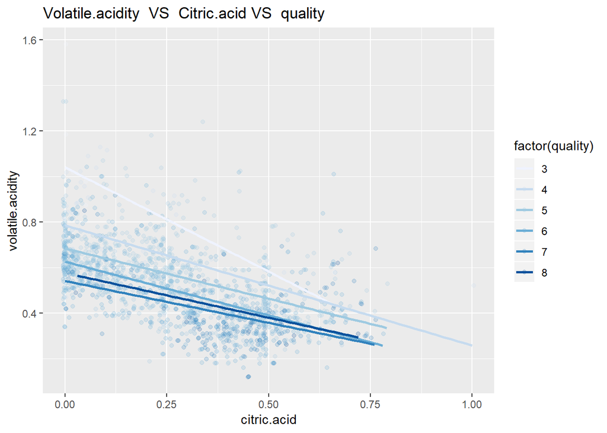

```r
ggplot(aes(x = citric.acid, y = volatile.acidity, color = factor(quality)), data = pf) +
  geom_jitter(alpha = 0.2) +
  scale_color_brewer(palette = "Blues") +
  geom_smooth(method = "lm", se = FALSE,size=1) +
  labs(y = 'volatile.acidity',x = 'citric.acid') +
  ggtitle("Volatile.acidity  VS  Citric.acid VS  quality")
```

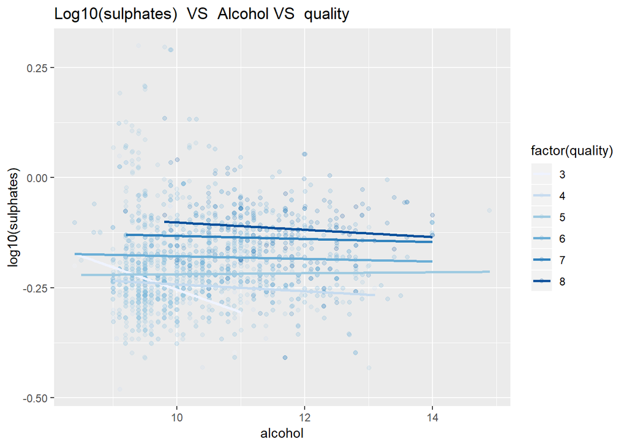

```r
ggplot(aes(x = alcohol, y = log10(sulphates), color = factor(quality)), data = pf) +
  geom_jitter(alpha = 0.2) +
  scale_color_brewer(palette = "Blues") +
  geom_smooth(method = "lm", se = FALSE,size=1) +
  labs(y = 'log10(sulphates)',x = 'alcohol') +
  ggtitle("Log10(sulphates)  VS  Alcohol VS  quality")
```

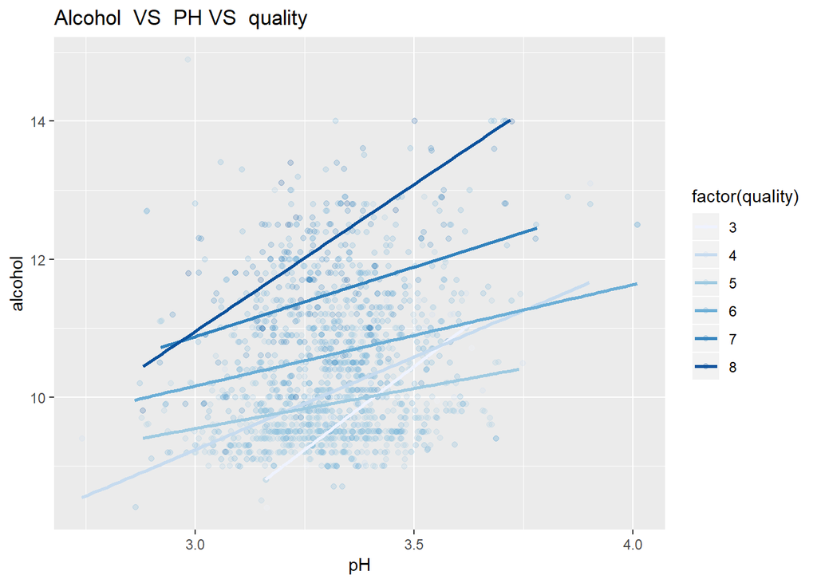

```r
ggplot(aes(x = pH, y = alcohol, color = factor(quality)), data = pf) +
  geom_jitter(alpha = 0.2) +
  scale_color_brewer(palette = "Blues") +
  geom_smooth(method = "lm", se = FALSE,size=1) +
  labs(y = 'alcohol',x = 'pH') +
  ggtitle("Alcohol  VS  PH VS  quality")
```

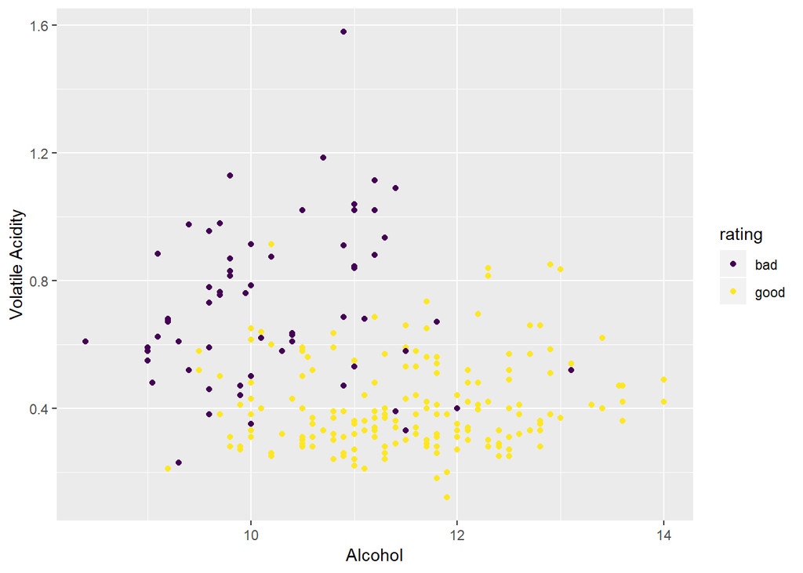

```r
ggplot(data = subset(pf, rating != 'average'),
       aes(x = alcohol, y = volatile.acidity, color = rating)) +
  geom_point() +
  xlab('Alcohol') +
  ylab('Volatile Acidity')
```

## 多变量分析

多变量图，通过把质量分数分图，通过3个评级类别进行分析，可以看到，较高的alcohol, sulphates, citric acid, fixed acidity，较低的volatile acidity可以产生更高质量的葡萄酒。ph对质量的影响很小，这个很意外； 最后一图去掉中级后，更能明显看出低挥发性酸度volatile acid和高酒精含量alcohol对质量的影响。

## 最终成图

### 结论一 酸度影响葡萄酒质量

根据双变量分析结论，fixed acidity, citric acid与葡萄酒质量正相关，volatile acidity ，pH 跟质量是负相关的。绘制出相应线箱图

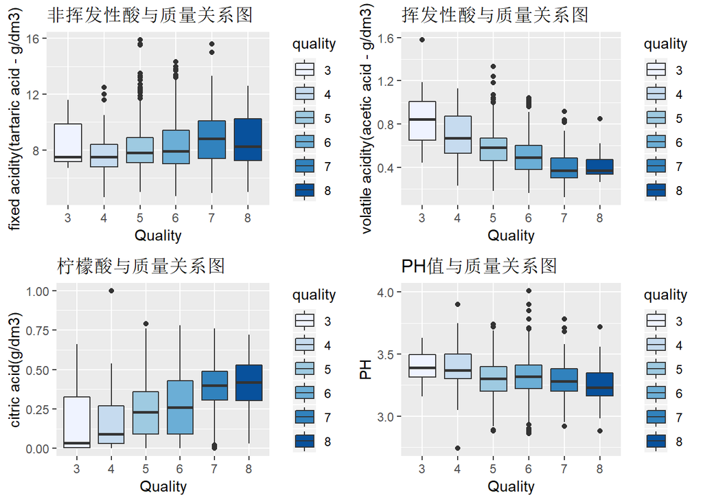

```r
grid.arrange(ggplot(data = pf, aes(x = quality, y = fixed.acidity, fill = quality)) +
               scale_fill_brewer(palette = "Blues")+
               xlab('Quality') +
               ylab('fixed acidity(tartaric acid - g/dm³)') +
               ggtitle('非挥发性酸与质量关系图')+
               geom_boxplot(),
             ggplot(data = pf, aes(x = quality, y = volatile.acidity, fill = quality)) +
               scale_fill_brewer(palette = "Blues")+
               xlab('Quality') +
               ylab('volatile acidity(acetic acid - g/dm³)') +
               ggtitle('挥发性酸与质量关系图')+
               geom_boxplot(),
             ggplot(data = pf, aes(x = quality, y = citric.acid, fill = quality)) +
               scale_fill_brewer(palette = "Blues")+
               xlab('Quality') +
               ylab('citric acid(g/dm³)') +
               ggtitle('柠檬酸与质量关系图') +
               geom_boxplot(),
             ggplot(data = pf, aes(x = quality, y = pH, fill = quality)) +
               scale_fill_brewer(palette = "Blues")+
               xlab('Quality') +
               ylab('PH') +
               ggtitle('PH值与质量关系图')+
               geom_boxplot())
```

- 高质量的葡萄酒有较高的酸acid或更低的ph；
- 其中柠檬酸citric acid 的影响更大，固定酸fixed acid 影响较小；
- 但是，挥发性酸volatile acidity不利于葡萄酒质量；